# About

Conditions:  
e (OnomatoAspect)  
a. for x once  
b. for x twice  
c. after x once  
d. after x twice

e 1 a  
1分間|生徒が|ちらっと|黒板を|見たので|先生が|カンニングを|疑った。  
? 生徒は黒板を1分間見た Y  
e 1 b  
1分間|生徒が|ちらちら|黒板を|見たので|先生が|カンニングを|疑った。  
? 生徒は黒板を1分間見た Y  
e 1 c  
1分後|生徒が|ちらっと|黒板を|見たので|先生が|カンニングを|疑った。  
? 生徒は黒板を1分間見た N  
e 1 d  
1分後|生徒が|ちらちら|黒板を|見たので|先生が|カンニングを|疑った。  
? 生徒は黒板を1分間見た N

gano (16 items)  
a. no x manner  
b. no x locative  
c. ga x manner  
d. ga x locative

gano 1 a  
部長の|先月|こっそり|飲んだ|お酒は|取引先からの|差し入れだった。  
? 部長が飲んだお酒は取引先からの差し入れである Y  
gano 1 b  
部長の|先月|会議室で|飲んだ|お酒は|取引先からの|差し入れだった。  
? 部長が飲んだお酒は取引先からの差し入れである Y  
gano 1 c  
部長が|先月|こっそり|飲んだ|お酒は|取引先からの|差し入れだった。  
? 部長が飲んだお酒は取引先からの差し入れである Y  
gano 1 d  
部長が|先月|会議室で|飲んだ|お酒は|取引先からの|差し入れだった。  
? 部長が飲んだお酒は取引先からの差し入れである Y

# Retrieve RT data into alldata

First concatenate all the `.data` files into `alldata.txt`. You can do it in a shell with:

cat *.dat > alldata.txt

##### Load libraries

```r
library(lme4)
library(xtable)
library(plyr)
library(dplyr)
```

```r
library(ggplot2)
library(reshape)
library(gdata)
library(MASS)
```

##### Load data:

```r
alldata<-read.csv("onom2022.csv",comment.char = "#",
                 header=TRUE)
```

####い必要な行を取り出す

```r
data<-alldata %>%
  dplyr::select(hash, controllername, type, property, sentence, value, code, item, correct, rt)
```

#### Check subjdata

```r
subjdata<- data %>%
  filter(property == "language"| property=="age")
```

```r
language<-subset(data, data$property=="language")
unique(language$value)
```

```
## [1] "日本語"
```

```r
subset(language, language$value!="日本語")
```

```
##  [1] hash           controllername type           property       sentence
##  [6] value          code           item           correct        rt
## <0 rows> (or 0-length row.names)
```

```r
data$value<-as.numeric(data$value)
```

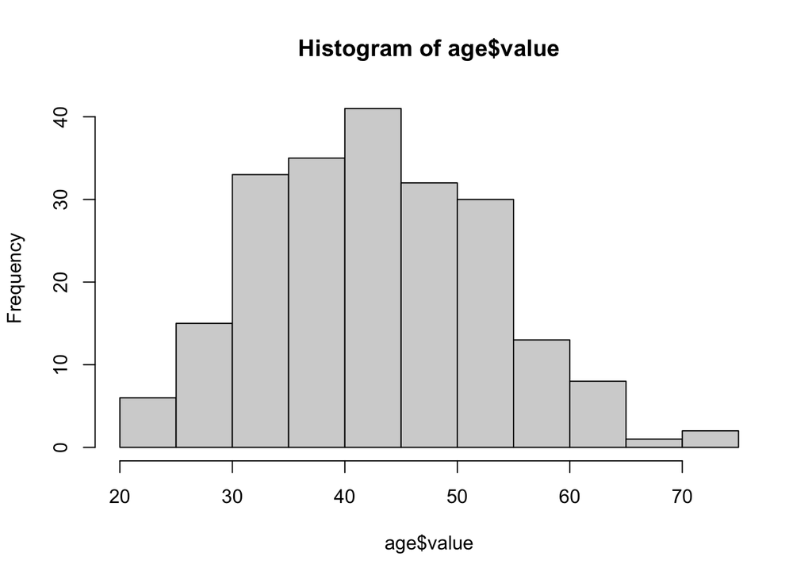

```r
age<-subset(data, data$property=="age"& data$sentence=="Final")
hist(age$value)
```

```r
mean(age$value, na.rm=TRUE)
```

```
## [1] 43.18981
```

```r
subset(age, is.na(age$value))
```

```
##                                   hash controllername  type property sentence
## 12599 336343558e0dc0fb7d59ff15f587d527 PennController intro      age    Final
## 13273 7660e3ad0ee831a58e8227e71b198d85 PennController intro      age    Final
## 35996 5271cf5e246a24bc4d40e7385c01949e PennController intro      age    Final
## 45667 3d122dd14110a8c07b7d1c5e34e1b146 PennController intro      age    Final
## 47917 21b26dc94e619afb76db63d33996f792 PennController intro      age    Final
##       value       code item correct rt
## 12599    NA yc9886r29c NULL         NA
## 13273    NA 0j2o5zb64w NULL         NA
## 35996    NA 4x271974xi NULL         NA
## 45667    NA 55qt3pe684 NULL         NA
## 47917    NA y06wy1xp46 NULL         NA
```

## omprehension Accuracy per subject

##### 変数初期化

```r
CAdataframe <- c();
myCA <- c()
myCAdataframe <- c()
```

##### Each subjのFillerのComprehension Accuracy情報を付加

Fillerにはcorrect answerがあるので，correctコラムに正解か不正解か(1,0)が入っている

```r
data$correct<-as.numeric(data$correct)
subset(data,type=="filler")
```

[output not shown]

[output cut: 29986 more lines]

```r
CAdataframe<-ddply(subset(data,type=="filler"& correct>=0),.(code),summarize,SubjCA=mean(correct))
```

##### asteriskを加える (outlier indication)

```r
CAdataframe<-data.frame(CAdataframe, CAmark=ifelse(CAdataframe$SubjCA<0.7, "**", ifelse(CAdataframe$SubjCA<0.8, "*" , " ")));
```

##### Merge CA data with `data`

```r
data <- merge(data,CAdataframe,all=T);
write.csv(data,file="data.csv",quote=F)
```

##### 変数初期化

```r
Itemdataframe<- c();
```

##### fillerの正答率で削る

```r
length(unique(data$code))
```

```
## [1] 221
```

```r
data<-subset(data,SubjCA>0.9)
length(unique(data$code))
```

```
## [1] 180
```

##### Each itemのvalue情報を付加

```r
Itemdataframe<-ddply(subset(data,type=="target"& value>=0),.(item),summarize, Itemvalue=mean(value))
```

####dataから必要な列のみを取り出す

```r
Itemsentence<-subset(data, type=="target" & property=="AcceptabilityJudgment" & sentence!="NULL")
```

####必要な行を取り出す

```r
Itemsentence<-Itemsentence %>%
  dplyr::select(sentence, item)
```

##### Merge

```r
Itemdataframe<-merge(Itemdataframe,Itemsentence,by.x="item")
```

####重複している列を削除する

```r
Itemdataframe<-distinct(Itemdataframe)
```

```r
Itemdataframe$z<-scale(Itemdataframe$Itemvalue,center=T,scale=1)[,1]
write.csv(Itemdataframe,file="itemdata.csv",quote=F)
```